# Predicting the Quality Score of Red Wine

**Introduction**

A 2022 study conducted by John Dunham and Associates found that the wine industry accounts for $276.07 billion economic output in America. While wine is a cornerstone of the US economy, few individuals are actually experts in the subject, with only 269 Master Sommeliers in the world. There is a clear disconnect between the economic impact of wine, and the number of individuals trained to assess a wine's quality, leaving room for restaraunts, liquor stores, and wineries to over (or under) price wines for consumers. During our project, we will be using predictors that could be found by contacting wine producers to see if we can predict the quality (0-10) of a red wine using regression.

**Preliminary Exploratory Data Analysis:**

```r
#loading necessary packages
set.seed(4789)
library(repr)
library(tidyverse)
library(tidymodels)
install.packages("corrplot")
library(corrplot)
library(GGally)
library(cowplot)
library(broom)
options(repr.matrix.max.rows = 6)
```

```
• Use tidymodels_prefer() to resolve common conflicts.

Updating HTML index of packages in '.Library'

Making 'packages.html' ...
 done
```

```r
#reading wine_data
url <- "https://archive.ics.uci.edu/ml/machine-learning-databases/wine-quality/winequality-red.csv"
wine_data <- read_delim(url, skip = 1, delim = ";",
                       col_names = c("fixed_acidity",
                                     "volatile_acidity",
                                     "citric_acid",
                                     "residual_sugar",
                                     "chlorides",
                                     "free_sulfur_dioxide",
                                     "total_sulfur_dioxide",
                                     "density",
                                     "pH",
                                     "sulphates",
                                     "alcohol",
                                     "quality")) |>
              mutate(across("fixed_acidity":"quality", as.numeric))
wine_data
```

A tibble: 1599 × 12

| fixed_acidity <dbl> | volatile_acidity <dbl> | citric_acid <dbl> | residual_sugar <dbl> | chlorides <dbl> | free_sulfur_dioxide <dbl> | total_sulfur_dioxide <dbl> | density <dbl> | pH <dbl> | sulphates <dbl> | alcohol <dbl> | quality <dbl> |
| --- | --- | --- | --- | --- | --- | --- | --- | --- | --- | --- | --- |
| 7.4 | 0.70 | 0.00 | 1.9 | 0.076 | 11 | 34 | 0.9978 | 3.51 | 0.56 | 9.4 | 5 |
| 7.8 | 0.88 | 0.00 | 2.6 | 0.098 | 25 | 67 | 0.9968 | 3.20 | 0.68 | 9.8 | 5 |
| 7.8 | 0.76 | 0.04 | 2.3 | 0.092 | 15 | 54 | 0.9970 | 3.26 | 0.65 | 9.8 | 5 |
| ⋮ | ⋮ | ⋮ | ⋮ | ⋮ | ⋮ | ⋮ | ⋮ | ⋮ | ⋮ | ⋮ | ⋮ |
| 6.3 | 0.510 | 0.13 | 2.3 | 0.076 | 29 | 40 | 0.99574 | 3.42 | 0.75 | 11.0 | 6 |
| 5.9 | 0.645 | 0.12 | 2.0 | 0.075 | 32 | 44 | 0.99547 | 3.57 | 0.71 | 10.2 | 5 |
| 6.0 | 0.310 | 0.47 | 3.6 | 0.067 | 18 | 42 | 0.99549 | 3.39 | 0.66 | 11.0 | 6 |

Table 1. Table of quantitative wine qualities from the full wine dataset.

```r
#splitting wine data into training/testing
wine_split <- initial_split(wine_data, prop = 0.75, strata = quality)
wine_training <- training(wine_split)
wine_testing <- testing(wine_split)
```

```r
#summarizing the training dataset

wine_max <- wine_training |>
            summarize(across("fixed_acidity":"quality", max, na.rm = TRUE))

wine_min <- wine_training |>
            summarize(across("fixed_acidity":"quality", min, na.rm = TRUE))

wine_mean <- wine_training |>
             summarize(across("fixed_acidity":"quality", mean, na.rm = TRUE))

wine_sd <- wine_training |>
             summarize(across("fixed_acidity":"quality", sd, na.rm = TRUE))

wine_summary <- bind_rows(wine_min, wine_mean, wine_max, wine_sd)
wine_summary
```

A tibble: 4 × 12

| fixed_acidity <dbl> | volatile_acidity <dbl> | citric_acid <dbl> | residual_sugar <dbl> | chlorides <dbl> | free_sulfur_dioxide <dbl> | total_sulfur_dioxide <dbl> | density <dbl> | pH <dbl> | sulphates <dbl> | alcohol <dbl> | quality <dbl> |
| --- | --- | --- | --- | --- | --- | --- | --- | --- | --- | --- | --- |
| 4.600000 | 0.1200000 | 0.0000000 | 0.900000 | 0.01200000 | 1.00000 | 6.00000 | 0.990070000 | 2.7400000 | 0.3300000 | 8.40000 | 3.0000000 |
| 8.274875 | 0.5292571 | 0.2673122 | 2.505050 | 0.08690317 | 16.10601 | 47.34349 | 0.996708581 | 3.3161352 | 0.6554174 | 10.43147 | 5.6343907 |
| 15.900000 | 1.3300000 | 1.0000000 | 15.500000 | 0.61000000 | 72.00000 | 289.00000 | 1.003200000 | 4.0100000 | 2.0000000 | 14.90000 | 8.0000000 |
| 1.731210 | 0.1781927 | 0.1925504 | 1.303993 | 0.04540641 | 10.40361 | 33.44410 | 0.001867152 | 0.1549522 | 0.1647294 | 1.06360 | 0.7956981 |

Table 2. The above table is a summary of the training dataset.

The first row is the minimum value of each variable, the second row is the mean value of each variable, the third row is the maximum value of each variable, and the fourth row is the standard deviation of each variable. This lets us know the range and distribution of values we should expect to see for each variable when we do our analysis.

Looking at the table, the scales of some variables differ greatly, which means that scaling the data is an absolute necessity when performing preprocessing for KNN regression in order to ensure that certain predictors do not influence our model more on the basis of their scale only.

The range and distribution of the target variable (quality) indicates the range of quality scores where the predictive model will be able to make the most accurate predictions, as any predictive model is much less likely to be able to make accurate predictions for values that the model received little to no training on. We can further analyze the distribution of quality scores by creating a histogram.

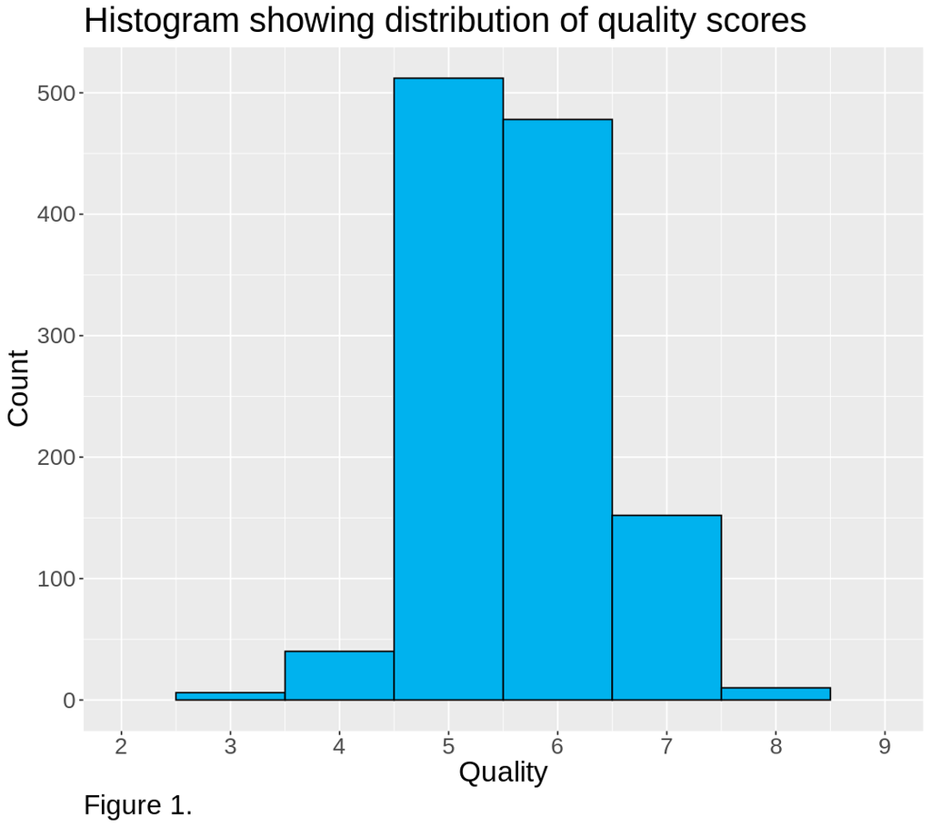

```r
#creating a histogram to show the distrubtion of quality scores
options(repr.plot.width = 9, repr.plot.height = 8)
quality_hist <- wine_training |>
                    ggplot(aes(x = quality)) +
                    geom_histogram(binwidth = 1, fill = "deepskyblue2", col = "black") +
                    theme(text = element_text(size = 20),
                          plot.caption = element_text(size = 19, hjust = 0)) +
                    labs(x = "Quality",
                         y= "Count",
                         title = "Histogram showing distribution of quality scores",
                         caption = "Figure 1.") +
                    scale_x_continuous(breaks = c(2,3,4,5,6,7,8,9), lim = c(2,9))
quality_hist
```

Figure 1. A histogram showing the distribution of quality scores in the training dataset.

We notice an imbalance in our data, with the vast majority of values being between 5 and 7. This imbalance would affect our data analysis, so we expect our model to predict best if the true quality score is around 5 to 7.

```r
# making a correlation plot
corr <- cor(wine_training)
colnames(corr)<- c("Fixed Acidity", "Volatile Acidity", "Citric Acid", "Residual Sugar", "Chlorides", "Free Sulfur Dioxide", "Total Sulfur Dioxide","Density", "pH", "Sulphates", "Alcohol", "Quality")
rownames(corr)<- c("Fixed Acidity", "Volatile Acidity", "Citric Acid", "Residual Sugar", "Chlorides", "Free Sulfur Dioxide", "Total Sulfur Dioxide","Density", "pH", "Sulphates", "Alcohol", "Quality")
round(corr, 2)
```

A matrix: 12 × 12 of type dbl

|  | Fixed Acidity | Volatile Acidity | Citric Acid | Residual Sugar | Chlorides | Free Sulfur Dioxide | Total Sulfur Dioxide | Density | pH | Sulphates | Alcohol | Quality |
| --- | --- | --- | --- | --- | --- | --- | --- | --- | --- | --- | --- | --- |
| Fixed Acidity | 1.00 | -0.25 | 0.66 | 0.07 | 0.11 | -0.17 | -0.11 | 0.66 | -0.68 | 0.18 | -0.09 | 0.10 |
| Volatile Acidity | -0.25 | 1.00 | -0.55 | 0.00 | 0.05 | -0.01 | 0.08 | 0.04 | 0.23 | -0.25 | -0.19 | -0.37 |
| Citric Acid | 0.66 | -0.55 | 1.00 | 0.12 | 0.20 | -0.06 | 0.05 | 0.35 | -0.54 | 0.29 | 0.08 | 0.19 |
| ⋮ | ⋮ | ⋮ | ⋮ | ⋮ | ⋮ | ⋮ | ⋮ | ⋮ | ⋮ | ⋮ | ⋮ | ⋮ |
| Sulphates | 0.18 | -0.25 | 0.29 | -0.03 | 0.38 | 0.04 | 0.04 | 0.14 | -0.19 | 1.00 | 0.09 | 0.24 |
| Alcohol | -0.09 | -0.19 | 0.08 | 0.05 | -0.23 | -0.06 | -0.21 | -0.52 | 0.22 | 0.09 | 1.00 | 0.47 |
| Quality | 0.10 | -0.37 | 0.19 | -0.02 | -0.15 | -0.05 | -0.19 | -0.20 | -0.02 | 0.24 | 0.47 | 1.00 |

Table 3. Correlation values between wine_training objects.

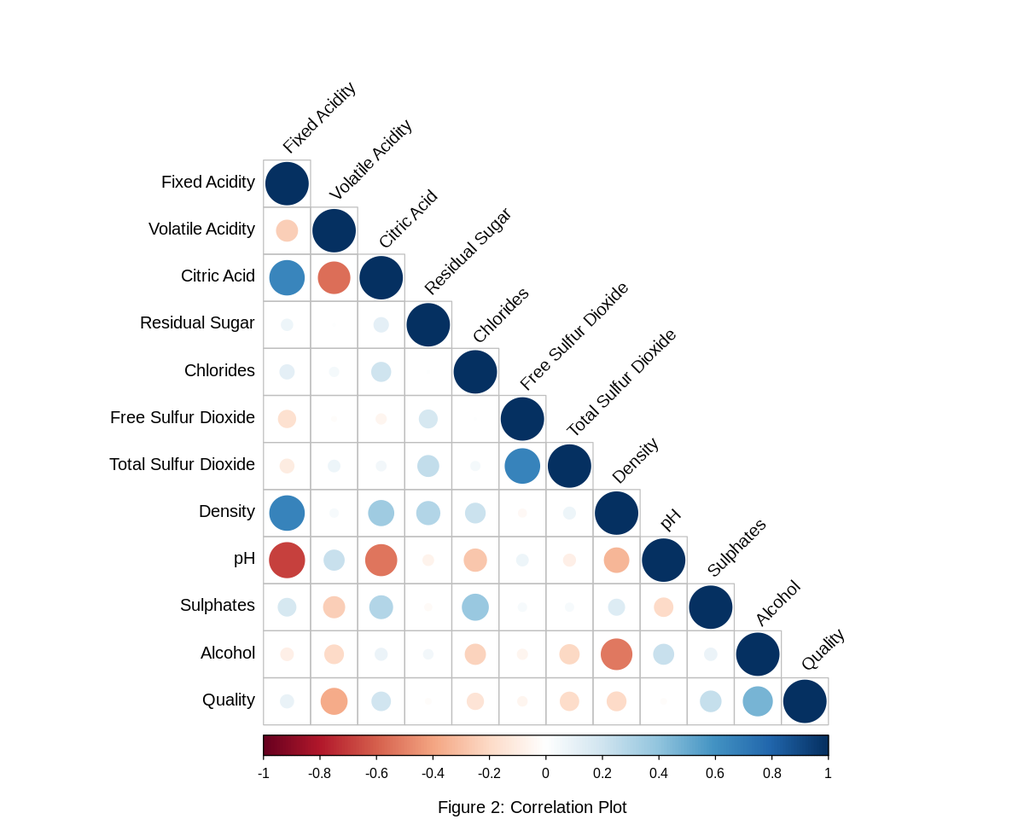

```r
options(repr.plot.width = 10, repr.plot.height = 8)
corrplot(corr, type = "lower",
         tl.col = "black", tl.srt = 45,)
title(sub = list("Figure 2: Correlation Plot", font= 25))
```

Figure 2. Correlation Plot (made using Table 3), On the x-axis, +1 means a strong positive correlation, and -1 means a strong negative correlation.

A correlation plot was generated to understand which predictors correlate strongly (either positively or negatively) to wine quality. Correlation provides insight as to which variables may be good predictors in our model. Alcohol, total sulfur dioxide, volatile acidity, citric acid, density, and sulphates are notably correlated to wine quality.

**Methods**

Building a good model requires a careful selection of relevant predictors. Our dataset contains 11 variables of which many are redundant. We will use both our insights and a correlation matrix to determine which ones to use.

Firstly, alcohol will be used, since it is known to impact individuals' perception of wine flavour, thus influencing perceived quality (Caballero & Segura, 2017). Secondly, total sulphur dioxide will be used, total sulphur dioxide acts as an antioxidant with probable impacts on quality (Araptisas et al., 2018). The correlation matrix also suggests that sulphates, volatile_acidity, citric_acid and density are significant. We will use these six variables as predictors to build our predictive model.

Since we are using six predictors, there is not an easy way to visually analyze the relationship between the predictors and target variable to determine whether linear regression or KNN regression would provide better predictions. Therefore, we will build and compare linear and KNN regression models to determine which model better suits our data.

**KNN Regression**

For the KNN regression model, we first need to find the number of neighbours that minimizes the RMSE value. We start by building the KNN regression model and creating a recipe with the training data to center and scale all the predictors. Then, we perform a 10-fold cross-validation and test the number of neighbours from 1 to 150. Finally, we add the recipe and the model to a workflow and get a tibble showing the RMSE values for different numbers of neighbours.

```r
# MAKING A K-NN REGRESSION MODEL
wine_spec_knn <- nearest_neighbor(weight_func = "rectangular", neighbors = tune()) |>
      set_engine("kknn") |>
      set_mode("regression")

# MAKING THE K-NN REGRESSION RECIPE
wine_recipe_knn <- recipe(quality ~ alcohol+ total_sulfur_dioxide +
                          volatile_acidity + citric_acid + density + sulphates , data = wine_training) |>
                   step_scale(all_predictors()) |>
                   step_center(all_predictors())

# PERFORMING CROSS-VALIDATION
wine_vfold <- vfold_cv(wine_training, v = 10, strata = quality)
gridvals <- tibble(neighbors = seq(1, 150))
wine_results_knn <- workflow() |>
                    add_recipe(wine_recipe_knn) |>
                    add_model(wine_spec_knn) |>
                    tune_grid(resamples = wine_vfold, grid = gridvals) |>
                    collect_metrics() |>
                    filter(.metric == "rmse")
```

```r
wine_results_knn
```

A tibble: 150 × 7

| neighbors <int> | .metric <chr> | .estimator <chr> | mean <dbl> | n <int> | std_err <dbl> | .config <chr> |
| --- | --- | --- | --- | --- | --- | --- |
| 1 | rmse | standard | 0.7864897 | 10 | 0.014339136 | Preprocessor1_Model001 |
| 2 | rmse | standard | 0.7053903 | 10 | 0.010732739 | Preprocessor1_Model002 |
| 3 | rmse | standard | 0.6823865 | 10 | 0.008287051 | Preprocessor1_Model003 |
| ⋮ | ⋮ | ⋮ | ⋮ | ⋮ | ⋮ | ⋮ |
| 148 | rmse | standard | 0.6612931 | 10 | 0.01177890 | Preprocessor1_Model148 |
| 149 | rmse | standard | 0.6614031 | 10 | 0.01181208 | Preprocessor1_Model149 |
| 150 | rmse | standard | 0.6614471 | 10 | 0.01183242 | Preprocessor1_Model150 |

Table 4. RMSE results following 10-fold cross-validation in KNN regression.

We arrange the RMSE values in ascending order and extract the number of neighbours for which the RMSE is lowest.

```r
# GETTING K FOR WHICH THE RMSE IS LOWEST.
wine_knn_min <- wine_results_knn |>
                arrange(mean) |>
                head(1) |>
                pull(neighbors)
wine_knn_min
```

15

The RMSE is minimized when the number of neighbours is 15, so we will choose k = 15 for the KNN regression model. We can plot the RMSE vs. the number of neighbours to visualize how the RMSE changes at different numbers of neighbours.

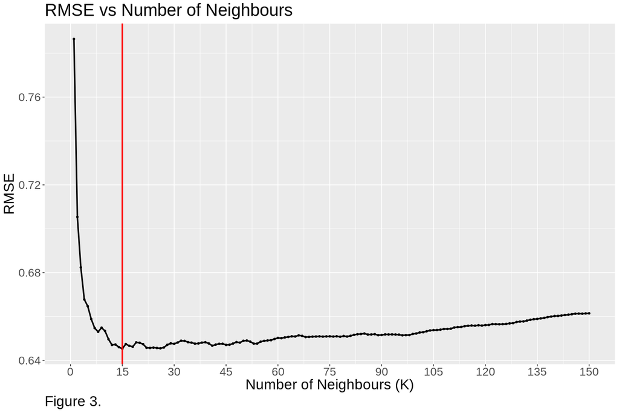

```r
# PLOTTING RMSE VS NEIGHBOURS TO VISUALISE RMSE VS NEIGHBOURS.
options(repr.plot.width = 12, repr.plot.height = 8)
wine_k_plot <- wine_results_knn |>
    ggplot(aes(x = neighbors, y = mean)) +
    geom_point(size = 1) +
    geom_line(size = 1) +
    geom_vline(xintercept = 15, colour = "red", size = 1) +
    labs(x = "Number of Neighbours (K)",
         y = "RMSE",
         title = "RMSE vs Number of Neighbours ", captions = "Figure 3.") +
    theme(text = element_text(size = 20),
          plot.caption = element_text(size = 20, hjust = 0)) +
    scale_x_continuous(breaks = c(0,15,30,45,60,75,90,105,120,135,150), lim= c(0,150))
wine_k_plot
```

Figure 3. This plot shows the RMSE (root mean square error) vs. the number of neighbors.

Using k = 15, we make a new KNN regression model, fit the model with the training dataset, make predictions on the testing dataset, and extract the RMSPE (root mean square prediction error) of the KNN regression model.

```r
# MAKING THE K-NN MODEL WITH IDEAL NUMBER OF NEIGHBOURS.
wine_best_spec_knn <- nearest_neighbor(weight_func = "rectangular", neighbors = wine_knn_min) |>
          set_engine("kknn") |>
          set_mode("regression")

# FITTING THE MODEL WITH THE TRAINING DATA.
wine_best_fit_knn <- workflow() |>
           add_recipe(wine_recipe_knn) |>
           add_model(wine_best_spec_knn) |>
           fit(data = wine_training)

# PREDICTING THE MODEL ON TESTING DATA.
wine_summary_knn <- wine_best_fit_knn |>
           predict(wine_testing) |>
           bind_cols(wine_testing) |>
           metrics(truth = quality, estimate = .pred)
wine_summary_knn

# GETTING THE RMSPE FROM K-NN REGRESSION.
wine_knn_rmse <- wine_summary_knn |>
                    filter(.metric == 'rmse') |>
                    pull()
wine_knn_rmse
```

A tibble: 3 × 3

| .metric <chr> | .estimator <chr> | .estimate <dbl> |
| --- | --- | --- |
| rmse | standard | 0.6671486 |
| rsq | standard | 0.3735247 |
| mae | standard | 0.5160432 |

0.667148620470365

Table 5. Tibble containing RMSPE of KNN regression model from the testing data when k = 15.

We get a RMSPE of 0.667148620470365 for the KNN regression model. We will now make a linear model and compare the RMSPE values of the KNN and linear regression models.

**Linear Regression**

For the linear regression model, we start by creating the linear regression model and recipe. Then, we fit the linear regression model to the training dataset, predict on the testing dataset, and finally, extract the RMSPE value of the linear regression model.

```r
#making the linear regression model
lm_spec <- linear_reg() |>
           set_engine("lm") |>
           set_mode("regression")

#making the linear regression recipe
lm_recipe <- recipe(quality ~ alcohol + total_sulfur_dioxide +
                    volatile_acidity + citric_acid + density + sulphates, data = wine_training)

#fitting the linear regression model to the training dataset
lm_fit <- workflow() |>
          add_recipe(lm_recipe) |>
          add_model(lm_spec) |>
          fit(wine_training)
lm_fit

#making predictions on the testing dataset and extracting the RMSPE
lm_rmspe <- lm_fit |>
            predict(wine_testing) |>
            bind_cols(wine_testing) |>
            metrics(truth = quality, estimate = .pred) |>
            filter(.metric == "rmse") |>
            select(.estimate) |>
            pull()

lm_rmspe
```

```
══ Workflow [trained] ══════════════════════════════════════════════════════════
Preprocessor: Recipe
Model: linear_reg()

── Preprocessor ────────────────────────────────────────────────────────────────
0 Recipe Steps

── Model ───────────────────────────────────────────────────────────────────────

Call:
stats::lm(formula = ..y ~ ., data = data)

Coefficients:
         (Intercept)               alcohol  total_sulfur_dioxide
            -5.28804               0.29671              -0.00216
    volatile_acidity           citric_acid               density
            -1.23185              -0.15553               8.18693
           sulphates
             0.70654
```

0.663290440156738

The RMSPE of the linear regression model is 0.663290440156738. The RMSPE of the linear regression model is lower than the RMPSE of the KNN regression model, so the linear regression model provides more accurate predictions of wine quality. Therefore, we will use the linear regression model.

**Results**

To visualize the results of our analysis, we will use a residual plot to determine how accurate our linear regression model is at predicting the wine quality as the true wine quality changes.

```r
# CREATING A TIBBLE WITH A NEW COLUMN CALLED "RESIDUALS"
lm_plot_prediction <- lm_fit |>
         predict(wine_testing) |>
         bind_cols(wine_testing) |>
         mutate(residuals = quality - .pred)
lm_plot_prediction
```

A tibble: 401 × 14

| .pred <dbl> | fixed_acidity <dbl> | volatile_acidity <dbl> | citric_acid <dbl> | residual_sugar <dbl> | chlorides <dbl> | free_sulfur_dioxide <dbl> | total_sulfur_dioxide <dbl> | density <dbl> | pH <dbl> | sulphates <dbl> | alcohol <dbl> | quality <dbl> | residuals <dbl> |
| --- | --- | --- | --- | --- | --- | --- | --- | --- | --- | --- | --- | --- | --- |
| 5.182317 | 7.8 | 0.76 | 0.04 | 2.3 | 0.092 | 15 | 54 | 0.9970 | 3.26 | 0.65 | 9.8 | 5 | -0.1823174 |
| 5.638498 | 11.2 | 0.28 | 0.56 | 1.9 | 0.075 | 17 | 60 | 0.9980 | 3.16 | 0.58 | 9.8 | 6 | 0.3615018 |
| 5.129925 | 7.4 | 0.70 | 0.00 | 1.9 | 0.076 | 11 | 34 | 0.9978 | 3.51 | 0.56 | 9.4 | 5 | -0.1299254 |
| ⋮ | ⋮ | ⋮ | ⋮ | ⋮ | ⋮ | ⋮ | ⋮ | ⋮ | ⋮ | ⋮ | ⋮ | ⋮ | ⋮ |
| 6.271698 | 7.4 | 0.350 | 0.33 | 2.4 | 0.068 | 9 | 26 | 0.99470 | 3.36 | 0.60 | 11.9 | 6 | -0.2716977 |
| 5.410203 | 6.8 | 0.620 | 0.08 | 1.9 | 0.068 | 28 | 38 | 0.99651 | 3.42 | 0.82 | 9.5 | 6 | 0.5897973 |
| 5.481691 | 5.9 | 0.645 | 0.12 | 2.0 | 0.075 | 32 | 44 | 0.99547 | 3.57 | 0.71 | 10.2 | 5 | -0.4816909 |

Table 6. A table containing residual values, testing set predictor values, and wine quality.

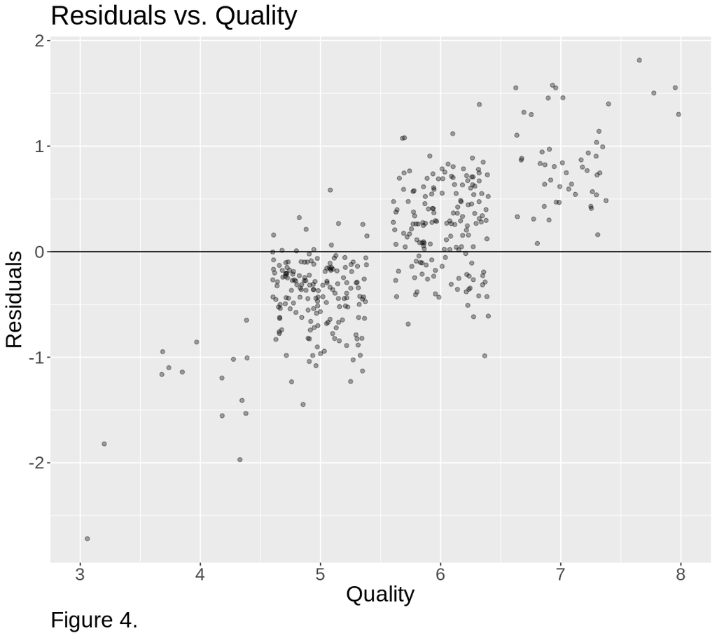

```r
# PLOTTING A RESIDUAL PLOT TO VISUALISE THE DISTRIBUTION OF RESIDUALS WITH RESPECT TO QUALITY.
options(repr.plot.width = 9, repr.plot.height = 8)
lm_residual_plot <- lm_plot_prediction |>
                    ggplot(aes(x = quality, y = residuals)) +
                    geom_point(alpha = 0.35, position = "jitter") +
                    geom_hline(yintercept= 0) +
                    labs(x = "Quality",
                         y = "Residuals",
                         title = "Residuals vs. Quality",
                         caption = "Figure 4.") +
                    theme(text = element_text(size = 20),
                          plot.caption = element_text(size = 20, hjust = 0)) +
                    scale_x_continuous(breaks = c(2,3,4,5,6,7,8), lim = c(3,8))
lm_residual_plot
```

Figure 4. A residual plot. The residuals are the difference between the actual and predicted data values. A residual plot allows us to visualize residuals, with the residuals on the vertical axis and the target variable (quality) on the horizontal axis. With the plot we can get a good idea of how well our regression model predicts and what are its biases. Residuals are closest to 0 when the true quality is around 5 to 6; this shows that our model best predicts when the true quality is around 5 to 6. Moreover, it seems than the prediction are biased towards these number, the prediction of wine of higher quality are mostly underestimated, and the wines of a lower quality are overestimated.

**Discussion**

Our correlation plot provided insight into potential predictors' correlation with wine quality. Importantly, when generating correlation plots, we are not implying that correlation is causation, but rather that correlation between potential predictors and wine quality act as a rationalization for our model creation. Using our correlation plot (Figure 2), we decided on using alcohol, total sulfur dioxide, volatile acidity, citric acid, density, and sulphates as our predictors for our model, given their correlation to quality. Given that wine quality is often determined by subjective taste, these predictors make sense as they are known to strongly influence the taste of wine.

Next, given that wine quality can be a number between 0-10, we decided that regression would be the optimal way to predict wine quality. However, we had to choose between KNN regression and multivariable linear regression.

We created a model using KNN regression using K = 15, as on our training data K = 15 produced the lowest RMSE (Figure 3). We then applied our model to our testing data using K = 15, and found an RMSPE of 0.667. Given the scale of our data (0-10), an RMSPE of 0.667 is relatively low and we deem it good for our model.

We decided that our multivariable linear regression model should be used to predict wine quality, given that the model had a smaller RMSPE. Interestingly, although the RMSPE for multiple linear regression was smaller, it was still highly similar to the RMSPE for K-NN Regression. It’s possible if our seed was set differently, we may have seen different results as to which model to choose.

Determining a way to evaluate our model (multivariable linear regression) at a scale that is in the scope of this class was tricky. Our model was evaluated using residuals (Figure 4), provided its ability to visualize our model's strength at different wine qualities. We found that our model performed best on testing data for wine qualities around 5 to 6, noted by the residuals being closer to 0 than at other wine qualities. As we had an unbalanced dataset with more wine of quality 5 and 6, varied prediction strength was expected.

The impact of our findings from the linear regression model could be significant. The model could be used by wine producers and sellers to make more informed decisions about the quality of their wines, which could help them to better target their products to specific markets or consumers. Furthermore, the model could be used to identify trends and patterns in the data that could be used to improve the production and marketing of wine. This could lead to increased sales and revenue for the wine industry as a whole, as well as for individual producers and sellers. Additionally, the model could be used by consumers to choose wines that are more likely to meet their expectations and preferences, which could lead to increased satisfaction and potentially even repeat purchases. All in all, our model prediction of wine quality has the potential to provide valuable insights and help drive decision-making in the wine industry, which could have positive economic impacts.

In future research, there are several potential questions that could be explored based on our findings. These include:

1. Can the model be improved by incorporating more data or additional predictors? For example, could the inclusion of weather or soil data improve the accuracy of the model?
2. How does the model perform on different types of wine, such as white, rose, or sparkling? Can the model be adapted to work with different types of wine, or do different models need to be developed for each type?
3. Can the model be used to predict wine quality for different regions or growing conditions? Can the model be used to identify specific factors that contribute to the quality of wine from a particular region or vineyard?

The future research could focus on exploring the potential applications and addressing the limitations of the model as well as finding ways to improve its accuracy and effectiveness. By addressing these questions, future research could help to expand the capabilities of the model and make it more useful for practical applications in the wine industry.

**Data Sources:**

P. Cortez, A. Cerdeira, F. Almeida, T. Matos and J. Reis. Modeling wine preferences by data mining from physicochemical properties. In Decision Support Systems, Elsevier, 47(4):547-553, 2009.

Arapitsas, P., Guella, G., & Mattivi, F. (2018). The impact of SO2 on wine flavanols and indoles in relation to wine style and age. Scientific Reports, 8(1), 858. https://doi.org/10.1038/s41598-018-19185-5

Caballero, A., & Segura, A. (2017). The quest for lower alcoholic wines. Microbial Biotechnology, 10(2), 238–241. https://doi.org/10.1111/1751-7915.12594

2022 economic impact study of the American wine industry methodology. WineAmerica. (2022, September 21). Retrieved October 28, 2022, from https://wineamerica.org/economic-impact-study/2022-american-wine-industry-methodology/

Members archive. Court of Master Sommeliers Europe. (n.d.). Retrieved October 28, 2022, from https://www.courtofmastersommeliers.org/members/

UCI Machine Learning Repository: Wine quality data set. (n.d.). Retrieved December 6, 2022, from https://archive.ics.uci.edu/ml/datasets/wine+quality